# Alvarez_Estevez_Sara_SAD_PEC4

Sara Álvarez Estévez

2023-12-31

Para el presente estudio utilizaremos un conjunto de datos obtenido de Biostat (https://hbiostat.org/data/). En este caso he seleccionado un dataset sobre la distrofia muscular de Duchenne, ya que siempre me ha gustado la genética médica y es un tema que me interesa y con el que me encuentro familiarizada.

### INTRODUCCIÓN

La distrofia muscular de Duchenne es una enfermedad muscular grave ligada al cromosoma X, es la distrofia muscular más frecuente en la infancia y afecta a 1 de cada 3500 recién nacidos varones. La DMD (siglas del inglés ‘Duchenne Muscular Dystrophy’) se produce por la ausencia o el defecto grave de la distrofina. Esto provoca daño en el sarcolema ante el estrés mecánico, pérdida de la homeostasis del calcio intracitoplasmático y, finalmente, degeneración de la fibra muscular. Esta fibra muscular se necrosa y los intentos de regeneración muscular son insuficientes, hasta que gran parte del tejido muscular normal es sustituido por tejido fibroadiposo. La distrofina se expresa fundamentalmente en el músculo esquelético y cardíaco, pero existen isoformas que se expresan selectivamente en otros órganos, como el cerebro, las células de Schwann o la retina. Esto justifica las manifestaciones no musculares asociadas a la DMD.

Salas, A. C. (2014). Distrofia muscular de Duchenne. Anales de Pediatría Continuada, 12(2), 47-54. https://doi.org/10.1016/s1696-2818(14)70168-4

Nuestros datos se recogen a partir de muestras de sangre obtenidas en un proyecto para desarrollar un programa de screening para mujeres familiares de hombres con DMD . Esto tiene un gran interés ya que la DMD se transmite genéticamente de madres a hijos. Al tratarse de una enfermedad con herencia recesiva ligada al X, las mujeres descendientes de una mujer portadora tienen un 50% de probabilidad de ser, asímismo, portadoras de la enfermedad, mientras que los hombres descendientes de una mujer portadora tienen un 50% de posibilidades de padecer la enfermedad.

Las mujeres que heredan el cromosoma X mutado, usualmente no sufren síntomas, por lo que pueden ser portadoras de la enfermedad sin conocerlo. Los hijos afectados con la enfermedad mueren en edades tempranas. Es por esto que es interesante poder detectar las mujeres portadoras del DMD, ya que usualmente la sospecha de serlo aparece cuando tienen ya un hijo afectado. Como hemos mencionado anteriormente, las portadoras del DMD usualmente no presentan síntomas físicos, pero tienden a tener niveles elevados de ciertas enzimas o proteínas del serum, como la creatina kinasa (CK), hemopexina(H),lactato deshidrogenasa(LD) y piruvato kinasa (PK).

### MÉTODOS

Para realizar nuestro estudio hemos descargado un dataset en formato csv, por lo que lo primero que haremos será importar nuestro dataset con la función “read.csv” y observar las variables que tenemos:

```r
dmd<-read.csv("C:/Users/Suruxx/Downloads/dmd.csv")
head(dmd)
```

```
##   X hospid age sdate ck         h       pk ld carrier obsno
## 1 1    657  27  6497 22  99.00000 10.79883 NA       0     1
## 2 2    667  31  6528 29  94.00000 11.79883 NA       0     1
## 3 3    669  22  6558 22  85.50000 15.00000 NA       0     1
## 4 4    671  25  6497 41  87.29688 15.00000 NA       0     1
## 5 5    673  26  6558 28  93.50000  7.00000 NA       0     1
## 6 6    675  38  6558 45 108.00000 13.69922 NA       0     1
```

Lo primero que hacemos es observar la estructura de los datos que tenemos

```r
dim(dmd)
```

```
## [1] 209  10
```

```r
names(dmd)
```

```
##  [1] "X"       "hospid"  "age"     "sdate"   "ck"      "h"       "pk"
##  [8] "ld"      "carrier" "obsno"
```

Como podemos observar, se trata de un conjunto de datos con 209 observaciones, para cada una de las cuales se nos presentan 10 variables:

- **X:** número de la observación
- **hospid**: ID hospitalario del paciente
- **age:** edad del paciente
- **sdate:** fecha en la que se toma la muestra
- **ck:** niveles de creatina quinasa
- **h:** niveles de hemopexina
- **pk:** niveles de piruvato quinasa
- **ld:** niveles de lactato deshidrogenasa
- **carrier:** estado de portadora (0=no 1=sí)
- **obsno:** número de observaciones del paciente

Además, podemos observar también que todas las variables son númericas, aunque podríamos consisderar carrier como factor.

Ahora que conocemos la estructura de nuestro conjunto de datos, nos interesa conocer más acerca de la información que contiene. Lo primero que haremos será comprobar si hay valores nulos o ‘missing values’:

```r
table(is.na(dmd))
```

```
##
## FALSE  TRUE
##  2075    15
```

```r
table(is.null(dmd))
```

```
##
## FALSE
##     1
```

Como podemos observar, tenemos 15 entradas con algún valor no disponible. Para facilitar los siguientes análisis, eliminaremos estas entradas de nuestro conjunto de datos.

```r
dmd=na.omit(dmd)
```

A continuación, observaremos la información más relevante sobre nuestro dataset.

```r
summary(dmd)
```

```
##        X              hospid            age            sdate
##  Min.   :  8.00   Min.   : 762.0   Min.   :20.00   Min.   :6589
##  1st Qu.: 56.25   1st Qu.: 910.2   1st Qu.:26.00   1st Qu.:6862
##  Median :104.50   Median :1009.0   Median :31.00   Median :7013
##  Mean   :104.74   Mean   :1051.1   Mean   :32.12   Mean   :6997
##  3rd Qu.:152.75   3rd Qu.:1251.5   3rd Qu.:36.00   3rd Qu.:7135
##  Max.   :202.00   Max.   :1447.0   Max.   :61.00   Max.   :7258
##        ck               h                pk               ld
##  Min.   :  15.0   Min.   : 34.00   Min.   :  2.80   Min.   : 66.0
##  1st Qu.:  30.0   1st Qu.: 78.82   1st Qu.: 10.30   1st Qu.:147.2
##  Median :  41.0   Median : 86.15   Median : 13.70   Median :176.5
##  Mean   :  90.1   Mean   : 85.98   Mean   : 16.22   Mean   :194.4
##  3rd Qu.:  73.0   3rd Qu.: 93.07   3rd Qu.: 17.80   3rd Qu.:227.0
##  Max.   :1288.0   Max.   :118.00   Max.   :110.00   Max.   :438.0
##     carrier           obsno
##  Min.   :0.0000   Min.   :1.000
##  1st Qu.:0.0000   1st Qu.:1.000
##  Median :0.0000   Median :1.000
##  Mean   :0.3454   Mean   :1.082
##  3rd Qu.:1.0000   3rd Qu.:1.000
##  Max.   :1.0000   Max.   :2.000
```

De este resultado nos interesa sobretodo los datos sobre las edades, para conocer mejor el grupo de estudio. Como vemos el rango de edad de las mujeres de nuestro estudio va desde los 20 años hasta los 61, aunque teniendo en cuenta que su tercer quartil es 36, podemos intuir que se trata de un grupo de mujeres jóvenes. Nos puede interesar también fijarnos en los diferentes estadísticos que describen los valores de los diferentes marcadores. Para comprobar los rangos de edad de las mujeres:

```r
table(dmd$age)
```

```
##
## 20 21 22 23 24 25 26 27 28 29 30 31 32 33 34 35 36 37 38 39 40 41 42 43 44 45
##  7  1 12  3  3 13 14 17  6  4 14 12 11  9  6 12  8  3  3 12  1  2  3  2  2  1
## 48 52 53 54 58 59 61
##  1  2  3  1  2  2  2
```

Como intuiamos, se trata principalmente de un grupo de mujeres jovenes, en edad reproductiva, ya que la mayoría de muestras pertenecen a individuos menores de 40 años. Nos interesa también conocer el número de individuos portadores y no portadores de los cuales se han obtenido datos:

```r
table(dmd$carrier)
```

```
##
##   0   1
## 127  67
```

Como vemos, la cantidad de individuos control es muchisimo más elevada que de individuos portadores. Nos interesa también conocer si la distribución de las edades es similar en ambos grupos para evitar posibles sesgos:

```r
dmd_control<-subset(dmd,dmd$carrier==0)
dmd_port<-subset(dmd,dmd$carrier==1)
table(dmd_control$age)
```

```
##
## 20 21 22 23 24 25 26 27 28 29 30 31 32 33 34 35 36 37 38 39
##  6  1 10  3  3 13 12 15  5  1  7 10  8  8  5  3  6  2  1  8
```

```r
table(dmd_port$age)
```

```
##
## 20 22 26 27 28 29 30 31 32 33 34 35 36 37 38 39 40 41 42 43 44 45 48 52 53 54
##  1  2  2  2  1  3  7  2  3  1  1  9  2  1  2  4  1  2  3  2  2  1  1  2  3  1
## 58 59 61
##  2  2  2
```

Como podemos observar, en el grupo de portadores estan bien distribuidos la cantidad de individuos dentro del rango de edad, sin embargo, en el caso del grupo control encontramos sobretodo muestras de mujeres jovenes, vemos que, por ejemplo, no hay ninguna persona por encima de 39 años entre ellas. Observaremos tambien como se distribuyen los datos dentro de cada subgrupo:

```r
summary(dmd_control)
```

```
##        X              hospid            age            sdate
##  Min.   :  8.00   Min.   : 762.0   Min.   :20.00   Min.   :6589
##  1st Qu.: 39.50   1st Qu.: 818.5   1st Qu.:25.00   1st Qu.:6862
##  Median : 77.00   Median : 936.0   Median :28.00   Median :7013
##  Mean   : 88.02   Mean   : 996.6   Mean   :28.88   Mean   :7004
##  3rd Qu.:145.50   3rd Qu.:1244.5   3rd Qu.:33.00   3rd Qu.:7135
##  Max.   :188.00   Max.   :1310.0   Max.   :39.00   Max.   :7258
##        ck               h                pk               ld           carrier
##  Min.   : 15.00   Min.   : 34.00   Min.   : 2.800   Min.   : 66.0   Min.   :0
##  1st Qu.: 27.00   1st Qu.: 76.00   1st Qu.: 9.649   1st Qu.:136.0   1st Qu.:0
##  Median : 34.00   Median : 82.00   Median :11.898   Median :162.0   Median :0
##  Mean   : 39.61   Mean   : 82.31   Mean   :12.145   Mean   :164.6   Mean   :0
##  3rd Qu.: 47.50   3rd Qu.: 90.15   3rd Qu.:15.299   3rd Qu.:185.0   3rd Qu.:0
##  Max.   :130.00   Max.   :111.50   Max.   :22.699   Max.   :349.0   Max.   :0
##      obsno
##  Min.   :1.000
##  1st Qu.:1.000
##  Median :1.000
##  Mean   :1.008
##  3rd Qu.:1.000
##  Max.   :2.000
```

```r
summary(dmd_port)
```

```
##        X             hospid          age            sdate            ck
##  Min.   : 49.0   Min.   : 902   Min.   :20.00   Min.   :6648   Min.   :  19.0
##  1st Qu.: 99.5   1st Qu.: 996   1st Qu.:30.00   1st Qu.:6832   1st Qu.:  55.0
##  Median :131.0   Median :1163   Median :35.00   Median :7013   Median : 101.0
##  Mean   :136.4   Mean   :1154   Mean   :38.27   Mean   :6984   Mean   : 185.8
##  3rd Qu.:182.0   3rd Qu.:1304   3rd Qu.:43.00   3rd Qu.:7105   3rd Qu.: 235.0
##  Max.   :202.0   Max.   :1447   Max.   :61.00   Max.   :7227   Max.   :1288.0
##        h                pk                ld           carrier      obsno
##  Min.   : 71.00   Min.   :  8.299   Min.   :122.0   Min.   :1   Min.   :1.000
##  1st Qu.: 86.40   1st Qu.: 14.299   1st Qu.:197.5   1st Qu.:1   1st Qu.:1.000
##  Median : 91.50   Median : 19.398   Median :243.0   Median :1   Median :1.000
##  Mean   : 92.93   Mean   : 23.931   Mean   :250.9   Mean   :1   Mean   :1.224
##  3rd Qu.:100.75   3rd Qu.: 25.248   3rd Qu.:290.5   3rd Qu.:1   3rd Qu.:1.000
##  Max.   :118.00   Max.   :110.000   Max.   :438.0   Max.   :1   Max.   :2.000
```

Si nos fijamos en los datos referentes a los cuatro marcadores, ya podemos apreciar esa tendencia a niveles más altos en el grupo de los portadores respecto al grupo control. Para observar mejor estas características, podemos representarlas gráficamente:

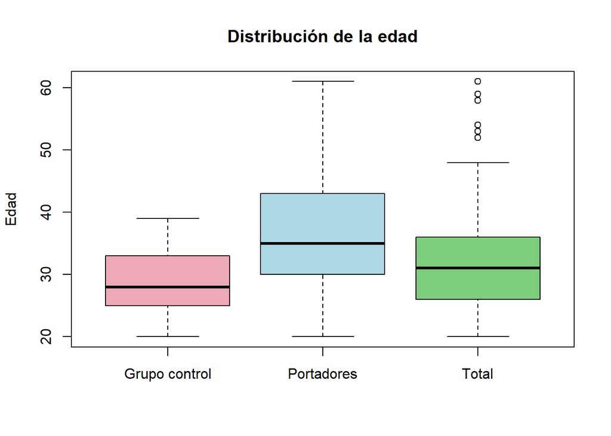

```r
library(ggplot2)
boxplot(dmd_control$age,dmd_port$age,dmd$age,names=c("Grupo control","Portadores","Total"),col=c("pink2","lightblue","palegreen3"),ylab="Edad",main="Distribución de la edad")
```

Ahora estudiaremos los niveles medidos en cada tipo de marcador:

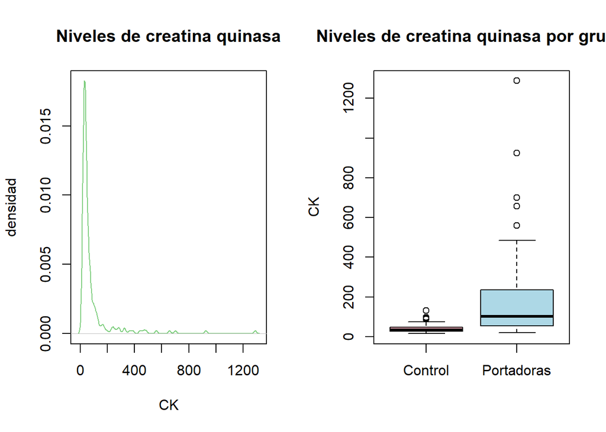

```r
par(mfrow=c(1,2))
plot(density(dmd$ck),main="Niveles de creatina quinasa",xlab="CK",ylab="densidad",col="palegreen3")
boxplot(dmd_control$ck,dmd_port$ck, names=c("Control","Portadoras"),ylab="CK",main="Niveles de creatina quinasa por grupo",col=c("pink2","lightblue"))
```

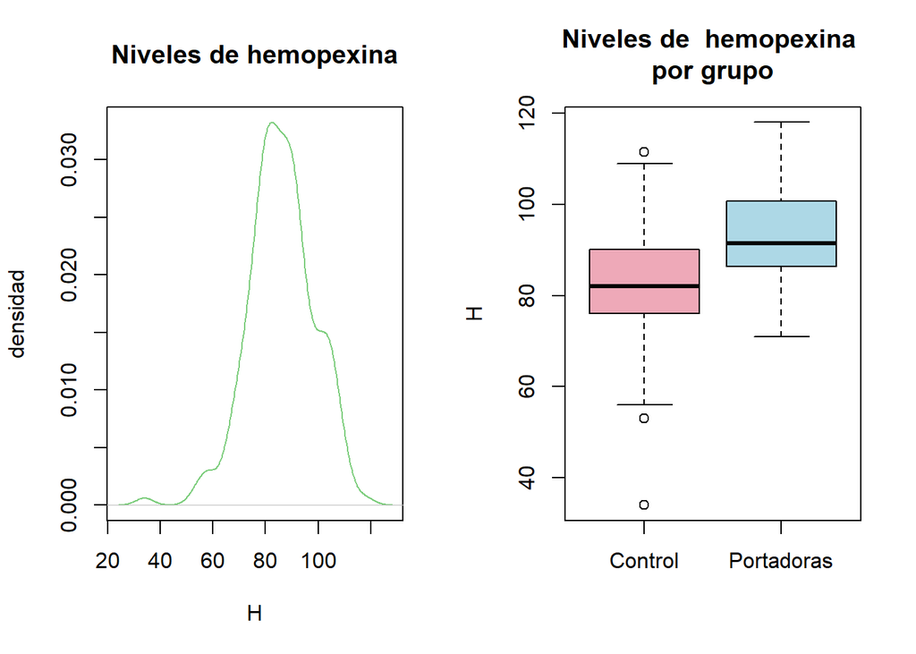

```r
par(mfrow=c(1,2))
plot(density(dmd$h),main="Niveles de hemopexina",xlab="H",ylab="densidad",col="palegreen3")
boxplot(dmd_control$h,dmd_port$h, names=c("Control","Portadoras"),ylab="H",main="Niveles de  hemopexina
por grupo",col=c("pink2","lightblue"))
```

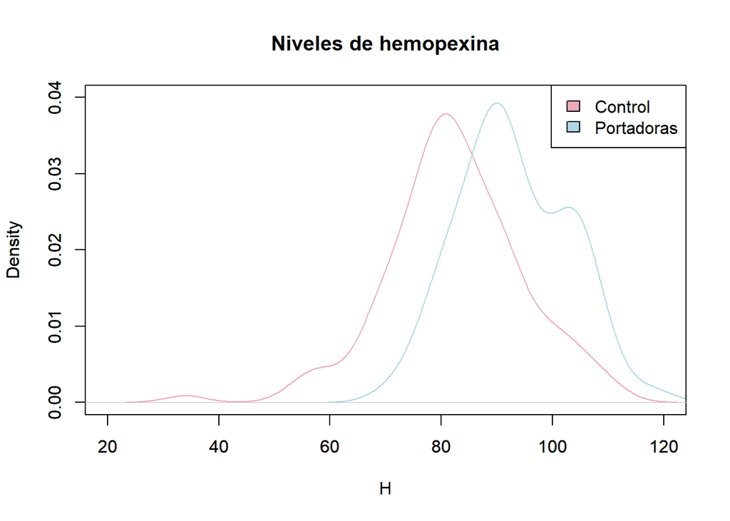

```r
plot(density(dmd_control$h),xlim=c(20,120),ylim=c(0,0.04),main="",xlab="H",col="pink2")
par(new=TRUE)
plot(density(dmd_port$h),xlim=c(20,120),ylim=c(0,0.04),main="Niveles de hemopexina",xlab="",col="lightblue")
legend(x="topright",legend = c("Control","Portadoras"),fill=c("pink2","lightblue"))
```

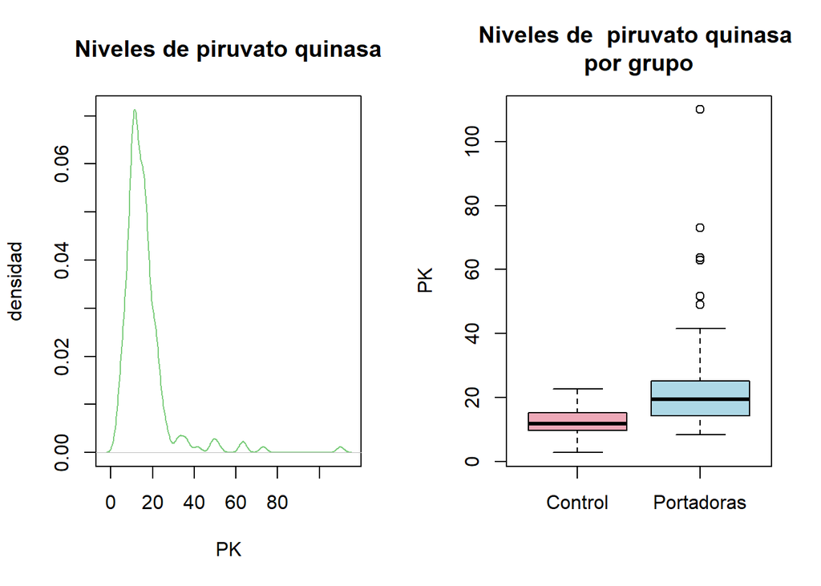

```r
par(mfrow=c(1,2))
plot(density(dmd$pk),main="Niveles de piruvato quinasa",xlab="PK",ylab="densidad",col="palegreen3")
boxplot(dmd_control$pk,dmd_port$pk, names=c("Control","Portadoras"),ylab="PK",main="Niveles de  piruvato quinasa
por grupo",col=c("pink2","lightblue"))
```

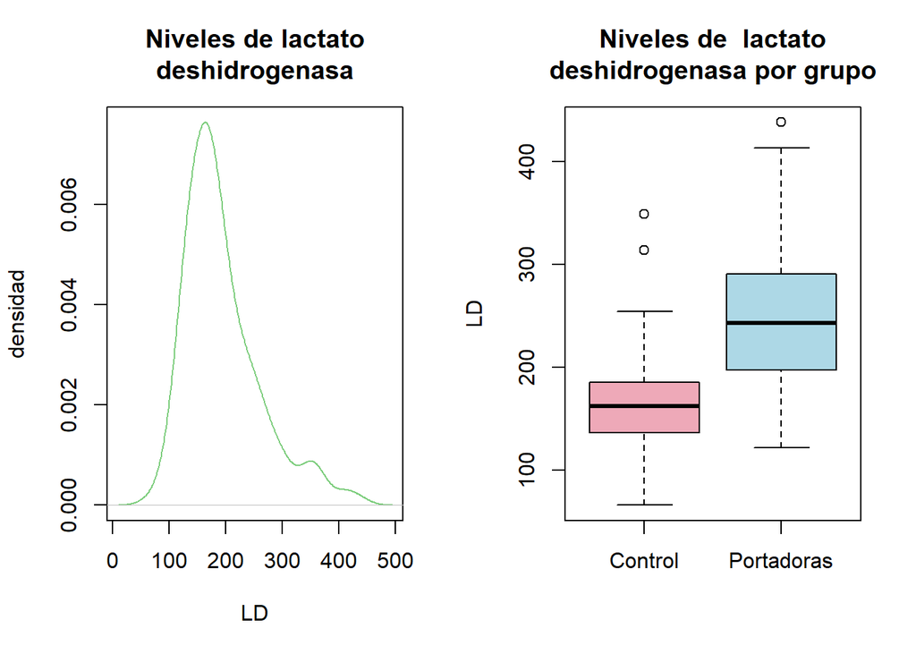

```r
par(mfrow=c(1,2))
plot(density(dmd$ld),main="Niveles de lactato
deshidrogenasa",xlab="LD",ylab="densidad",col="palegreen3")
boxplot(dmd_control$ld,dmd_port$ld, names=c("Control","Portadoras"),ylab="LD",main="Niveles de  lactato
deshidrogenasa por grupo",col=c("pink2","lightblue"))
```

Como podemos apreciar en los gráficos superiores, en todos los casos vemos una diferencia en los niveles de las portadoras respecto a los individuos sanos.

**PROBABILIDAD**

Dado nuestro conjunto de datos, si escogemos un individuo al azar, ¿cuál es la probabilidad de que este individuo sea un portador?

```r
table(dmd$carrier)
```

```
##
##   0   1
## 127  67
```

```r
pport<-67/(length(dmd$carrier))
pport
```

```
## [1] 0.3453608
```

La probabilidad de obtener un individuo portador es del 34,54%.

Supongamos que los niveles de hemopexina siguen una distribución normal, ¿cuál es la probabilidad de que si elegimos una portadora al azar sus niveles de hemopexina sean superiores a la media poblacional?

```r
#Como desconocemos la media poblacional, en este caso utilizaremos como su estimación la media del grupo de estudio.
mean(dmd_port$h)
```

```
## [1] 92.93027
```

```r
sd(dmd_port$h)
```

```
## [1] 9.857589
```

```r
mean(dmd$h)
```

```
## [1] 85.976
```

Si los niveles de hemopexina en las portadoras siguen una distribución normal con media 92,93 y desviación estándar 9,86, la probabilidad de que los niveles de hemopexina sean superiores a la media poblacional la calcularemos tal que:

```r
1-pnorm(mean(dmd$h),mean=mean(dmd_port$h),sd=sd(dmd_port$h)) #1-P(X<=85,976)
```

```
## [1] 0.7597423
```

Tenemos un 76% de posibilidades de que los niveles de hemopexina en portadoras sean superiores a la media total.

¿Y en el caso del grupo control?

```r
1-pnorm(mean(dmd$h),mean(dmd_control$h),sd(dmd_control$h)) #1-P(X<=85,976)
```

```
## [1] 0.3821912
```

En este caso, vemos que solo tenemos un 38% de probabilidad de estar por encima de la media. Como podemos observar, las portadoras tienen aproximadamente el doble de probabilidad de tener los niveles de hemopexina superiores a la media con respecto a las mujeres sanas. Podemos repetir este procedimiento para el resto de los marcadores:

```r
# Creatina quinasa
1-pnorm(mean(dmd$ck),mean=mean(dmd_port$ck),sd=sd(dmd_port$ck))
```

```
## [1] 0.6633748
```

```r
1-pnorm(mean(dmd$ck),mean(dmd_control$ck),sd(dmd_control$ck))
```

```
## [1] 0.003322196
```

```r
#Piruvato quinasa
1-pnorm(mean(dmd$pk),mean=mean(dmd_port$pk),sd=sd(dmd_port$pk))
```

```
## [1] 0.6730222
```

```r
1-pnorm(mean(dmd$pk),mean(dmd_control$pk),sd(dmd_control$pk))
```

```
## [1] 0.1770955
```

```r
#Lactato deshidrogenasa
1-pnorm(mean(dmd$ld),mean=mean(dmd_port$ld),sd=sd(dmd_port$ld))
```

```
## [1] 0.7824571
```

```r
1-pnorm(mean(dmd$ld),mean(dmd_control$ld),sd(dmd_control$ld))
```

```
## [1] 0.2354508
```

Podemor resumir los resultados obtenidos en la siguiente tabla:

| Marcadores | P>media controles | P>media portadoras |
| --- | --- | --- |
| Creatina quinasa | 0,33% | 66,34% |
| Hemopexina | 38,22% | 75,97% |
| Piruvato quinasa | 17,70% | 67,30% |
| Lactato deshidrogenasa | 23,54% | 78,25% |

Sabemos que 1 de cada 3500 niños nacen con DMD, en una población del tamaño de Barcelona, ¿cuántas personas serían afectadas por DMD?

```r
#Simulamos una población de 1,62M de individuos, con una probabilidad de padecer DMD de 1/3500
pdmd<-1/3500
psano<-1-pdmd
pob<-1620000
sim<-sample(c("dmd","sano"),pob,rep=T,prob=c(pdmd,psano))
table(sim)
```

```
## sim
##     dmd    sano
##     456 1619544
```

```r
psa<-1-pport
sim2<-sample(c("Portadora","Sana"),pob,rep=T,prob=c(pport,psa))
table(sim2)
```

```
## sim2
## Portadora      Sana
##    560092   1059908
```

En un población del tamaño de Barcelona, tendríamos alrededor de 560mil mujeres portadoras.

**REGRESIÓN LINEAL**

Como se mencionaba en la introducción, aunque las mujeres portadoras de DMD no suelen padecer síntomas, sin embargo si suelen tener niveles elevados de diferentes marcadores. Primeramente, nos interesa conocer si hay otros factores, como puede ser la edad, que también afecte los niveles de estos marcadores.

```r
cor(dmd,method="pearson")
```

```
##                  X     hospid         age       sdate         ck           h
## X       1.00000000 0.98661551  0.22865081  0.81672093 0.19003440  0.14649387
## hospid  0.98661551 1.00000000  0.20239965  0.80781935 0.19563835  0.11874933
## age     0.22865081 0.20239965  1.00000000 -0.02185691 0.17372421  0.30854478
## sdate   0.81672093 0.80781935 -0.02185691  1.00000000 0.02418128 -0.05308045
## ck      0.19003440 0.19563835  0.17372421  0.02418128 1.00000000  0.10547378
## h       0.14649387 0.11874933  0.30854478 -0.05308045 0.10547378  1.00000000
## pk      0.10771785 0.11639314  0.08488299 -0.08090427 0.72967013  0.16200420
## ld      0.35546227 0.34054899  0.30560616  0.08199580 0.55706133  0.28625056
## carrier 0.40888412 0.38551034  0.52266303 -0.05965116 0.46259808  0.40456730
## obsno   0.09419686 0.08564894  0.26994552 -0.11385145 0.14035940  0.18801685
##                  pk        ld     carrier       obsno
## X        0.10771785 0.3554623  0.40888412  0.09419686
## hospid   0.11639314 0.3405490  0.38551034  0.08564894
## age      0.08488299 0.3056062  0.52266303  0.26994552
## sdate   -0.08090427 0.0819958 -0.05965116 -0.11385145
## ck       0.72967013 0.5570613  0.46259808  0.14035940
## h        0.16200420 0.2862506  0.40456730  0.18801685
## pk       1.00000000 0.5649562  0.46583351  0.05955457
## ld       0.56495622 1.0000000  0.60660248  0.19751094
## carrier  0.46583351 0.6066025  1.00000000  0.37336728
## obsno    0.05955457 0.1975109  0.37336728  1.00000000
```

En este caso escogeremos comprobar la relación entre la edad y los niveles de hemopexina, ya que son los que presentan mayor correlación.

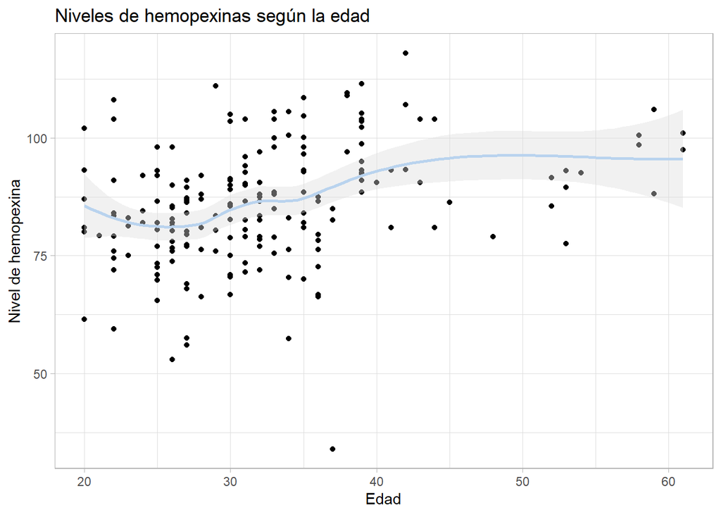

```r
library(ggplot2)
ggplot(dmd,aes(x=age, y=h))+geom_point()+geom_smooth(color="slategray2",fill="gainsboro")+theme_light()+labs(x="Edad",y="Nivel de hemopexina",title="Niveles de hemopexinas según la edad")
```

```r
modelo<-lm(dmd$h~dmd$age,data=dmd)
summary(modelo)
```

```
##
## Call:
## lm(formula = dmd$h ~ dmd$age, data = dmd)
##
## Residuals:
##     Min      1Q  Median      3Q     Max
## -54.176  -6.811   0.055   7.110  27.569
##
## Coefficients:
##             Estimate Std. Error t value Pr(>|t|)
## (Intercept)  71.4847     3.3361  21.427  < 2e-16 ***
## dmd$age       0.4511     0.1004   4.495  1.2e-05 ***
## ---
## Signif. codes:  0 '***' 0.001 '**' 0.01 '*' 0.05 '.' 0.1 ' ' 1
##
## Residual standard error: 11.94 on 192 degrees of freedom
## Multiple R-squared:  0.0952, Adjusted R-squared:  0.09049
## F-statistic:  20.2 on 1 and 192 DF,  p-value: 1.203e-05
```

Vemos que según nuestro modelo, la edad solo explicaría un 9% de la variación de los niveles de hemopexina.

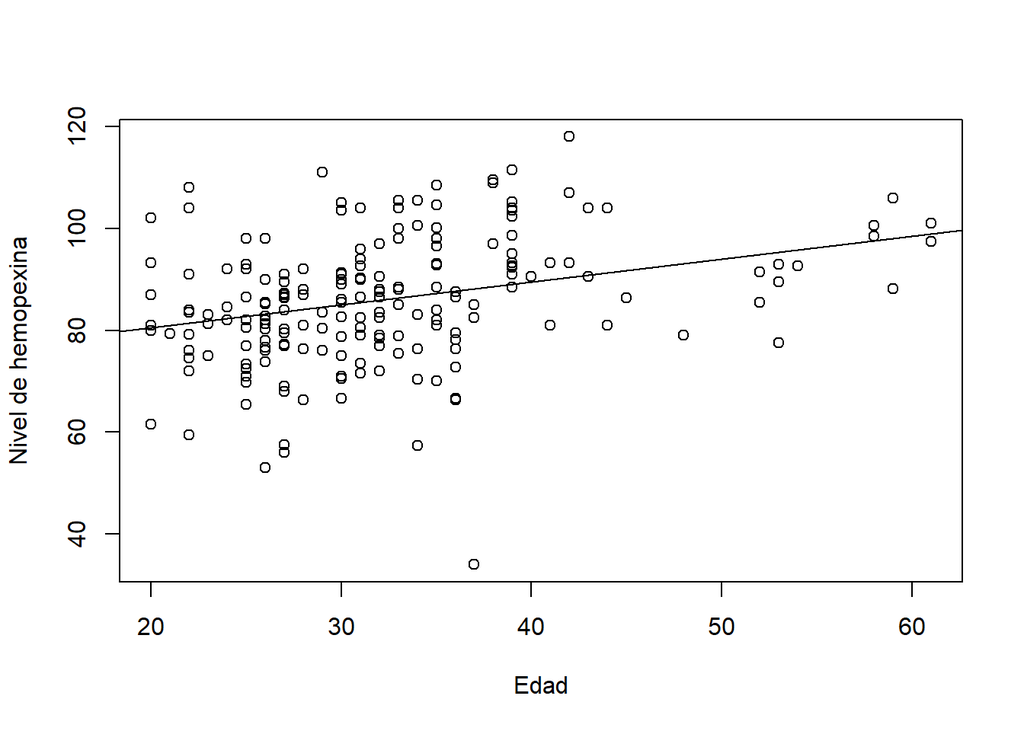

```r
plot(dmd$age,dmd$h,xlab="Edad",ylab="Nivel de hemopexina")
abline(modelo)
```

Siguiendo con el caso de los niveles de hemopexina, nos puede interesar conocer si estos vienen determinados por diferentes factores. Si observamos la matriz de correlaciones de pearson vemos que parece presentar mayor correlación lineal con *carrier*, que corresponde al indicador de portadoras. Generamos el modelo de regresión múltiple utilizando todas las variables:

```r
mrm_h<-lm(dmd$h~dmd$age+dmd$ck+dmd$pk+dmd$ld+dmd$carrier+dmd$sdate+dmd$obsno,data=dmd)
summary(mrm_h)
```

```
##
## Call:
## lm(formula = dmd$h ~ dmd$age + dmd$ck + dmd$pk + dmd$ld + dmd$carrier +
##     dmd$sdate + dmd$obsno, data = dmd)
##
## Residuals:
##     Min      1Q  Median      3Q     Max
## -50.156  -6.444  -0.361   7.001  27.904
##
## Coefficients:
##              Estimate Std. Error t value Pr(>|t|)
## (Intercept) 86.795759  37.586263   2.309  0.02203 *
## dmd$age      0.190939   0.116054   1.645  0.10161
## dmd$ck      -0.014644   0.008381  -1.747  0.08225 .
## dmd$pk       0.070653   0.109490   0.645  0.51953
## dmd$ld       0.022241   0.017242   1.290  0.19869
## dmd$carrier  7.829565   2.628355   2.979  0.00328 **
## dmd$sdate   -0.002219   0.005285  -0.420  0.67503
## dmd$obsno    1.590469   3.286643   0.484  0.62901
## ---
## Signif. codes:  0 '***' 0.001 '**' 0.01 '*' 0.05 '.' 0.1 ' ' 1
##
## Residual standard error: 11.43 on 186 degrees of freedom
## Multiple R-squared:  0.196,  Adjusted R-squared:  0.1657
## F-statistic: 6.477 on 7 and 186 DF,  p-value: 7.714e-07
```

Obtenemos un modelo con un coeficiente de determinación bastante bajo aunque con un p-valor bastante significativo. De entre todos estos predictores, seleccionamos los mejores:

```r
step(object = mrm_h,direction = "both",trace=1)
```

```
## Start:  AIC=953.2
## dmd$h ~ dmd$age + dmd$ck + dmd$pk + dmd$ld + dmd$carrier + dmd$sdate +
##     dmd$obsno
##
##               Df Sum of Sq   RSS    AIC
## - dmd$sdate    1     23.05 24337 951.39
## - dmd$obsno    1     30.61 24344 951.45
## - dmd$pk       1     54.43 24368 951.64
## - dmd$ld       1    217.50 24531 952.93
## <none>                     24314 953.20
## - dmd$age      1    353.84 24668 954.01
## - dmd$ck       1    399.05 24713 954.36
## - dmd$carrier  1   1159.97 25474 960.24
##
## Step:  AIC=951.39
## dmd$h ~ dmd$age + dmd$ck + dmd$pk + dmd$ld + dmd$carrier + dmd$obsno
##
##               Df Sum of Sq   RSS    AIC
## - dmd$obsno    1     37.89 24375 949.69
## - dmd$pk       1     70.22 24407 949.95
## - dmd$ld       1    199.74 24537 950.97
## <none>                     24337 951.39
## - dmd$age      1    356.44 24693 952.21
## - dmd$ck       1    424.75 24762 952.74
## + dmd$sdate    1     23.05 24314 953.20
## - dmd$carrier  1   1184.44 25521 958.61
##
## Step:  AIC=949.69
## dmd$h ~ dmd$age + dmd$ck + dmd$pk + dmd$ld + dmd$carrier
##
##               Df Sum of Sq   RSS    AIC
## - dmd$pk       1     58.24 24433 948.15
## - dmd$ld       1    199.99 24575 949.27
## <none>                     24375 949.69
## - dmd$age      1    372.72 24748 950.63
## - dmd$ck       1    410.33 24785 950.93
## + dmd$obsno    1     37.89 24337 951.39
## + dmd$sdate    1     30.33 24344 951.45
## - dmd$carrier  1   1411.92 25787 958.61
##
## Step:  AIC=948.15
## dmd$h ~ dmd$age + dmd$ck + dmd$ld + dmd$carrier
##
##               Df Sum of Sq   RSS    AIC
## <none>                     24433 948.15
## - dmd$ld       1    261.62 24695 948.22
## - dmd$age      1    327.89 24761 948.74
## - dmd$ck       1    380.08 24813 949.15
## + dmd$pk       1     58.24 24375 949.69
## + dmd$sdate    1     44.77 24388 949.80
## + dmd$obsno    1     25.91 24407 949.95
## - dmd$carrier  1   1568.02 26001 958.22
```

```
##
## Call:
## lm(formula = dmd$h ~ dmd$age + dmd$ck + dmd$ld + dmd$carrier,
##     data = dmd)
##
## Coefficients:
## (Intercept)      dmd$age       dmd$ck       dmd$ld  dmd$carrier
##    73.72075      0.17934     -0.01147      0.02346      8.59011
```

Se deriva que el mejor modelo con los predictores más significativos es el siguiente: lm(formula = dmd$h ~ dmd$age + dmd$ck + dmd$ld + dmd$carrier, data = dmd)

Si ejecutamos este modelo:

```r
pred<-lm(formula = dmd$h ~ dmd$age + dmd$ck + dmd$ld + dmd$carrier, data = dmd)
summary(pred)
```

```
##
## Call:
## lm(formula = dmd$h ~ dmd$age + dmd$ck + dmd$ld + dmd$carrier,
##     data = dmd)
##
## Residuals:
##     Min      1Q  Median      3Q     Max
## -50.001  -6.031  -0.391   7.249  27.928
##
## Coefficients:
##              Estimate Std. Error t value Pr(>|t|)
## (Intercept) 73.720753   4.274238  17.248  < 2e-16 ***
## dmd$age      0.179339   0.112607   1.593 0.112920
## dmd$ck      -0.011470   0.006689  -1.715 0.088044 .
## dmd$ld       0.023461   0.016492   1.423 0.156503
## dmd$carrier  8.590113   2.466499   3.483 0.000617 ***
## ---
## Signif. codes:  0 '***' 0.001 '**' 0.01 '*' 0.05 '.' 0.1 ' ' 1
##
## Residual standard error: 11.37 on 189 degrees of freedom
## Multiple R-squared:  0.1921, Adjusted R-squared:  0.175
## F-statistic: 11.23 on 4 and 189 DF,  p-value: 3.387e-08
```

**ANOVA**

Por último, haremos un estudio ANOVA para comprobar si realmente hay diferencias estadísticamente significativas de los niveles de los diferentes marcadores entre la población sana y las portadoras.

```r
ck_anova<-data.frame(dmd$carrier,dmd$ck)
```

Primero comprobaremos si la variable cuantitativa se distribuye de forma normal en cada grupo:

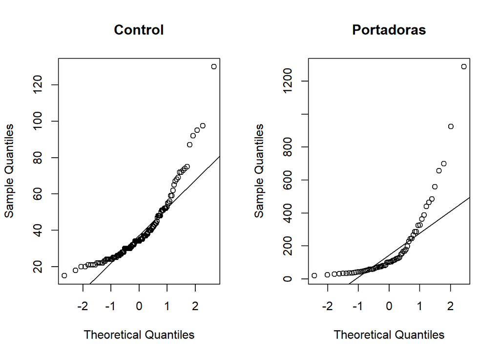

```r
par(mfrow=c(1,2))
qqnorm(ck_anova[ck_anova$dmd.carrier==0,"dmd.ck"],main="Control")
qqline(ck_anova[ck_anova$dmd.carrier==0,"dmd.ck"])
qqnorm(ck_anova[ck_anova$dmd.carrier==1,"dmd.ck"],main="Portadoras")
qqline(ck_anova[ck_anova$dmd.carrier==1,"dmd.ck"])
```

```r
#Como nuestra muestra es >50 utilizaremos el test de Kolmogorov-Smirnov para comprobar la normalidad
require(nortest)
by(data=ck_anova,INDICES = ck_anova$dmd.carrier,FUN=function(x){lillie.test(x$dmd.ck)})
```

```
## ck_anova$dmd.carrier: 0
##
##  Lilliefors (Kolmogorov-Smirnov) normality test
##
## data:  x$dmd.ck
## D = 0.16093, p-value = 1.369e-08
##
## ------------------------------------------------------------
## ck_anova$dmd.carrier: 1
##
##  Lilliefors (Kolmogorov-Smirnov) normality test
##
## data:  x$dmd.ck
## D = 0.2406, p-value = 2.102e-10
```

Como podemos ver, se detecta falta de normalidad en ambos grupos (p-valor < 0.05)

```r
# Realizamos el test Fligner-Killen para la diagnosis de homocedasticidad
fligner.test(ck_anova$dmd.ck~ck_anova$dmd.carrier,ck_anova)
```

```
##
##  Fligner-Killeen test of homogeneity of variances
##
## data:  ck_anova$dmd.ck by ck_anova$dmd.carrier
## Fligner-Killeen:med chi-squared = 84.604, df = 1, p-value < 2.2e-16
```

Detectamos también heterocedasticidad en las varianzas, debido a que no se cumplen las condiciones del anova, no proseguiremos con su estudio.

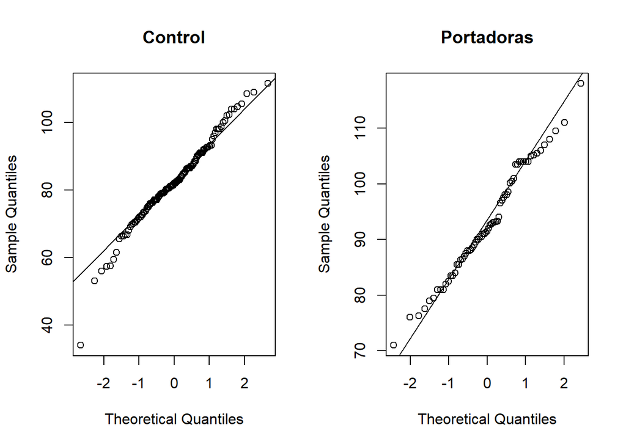

```r
h_anova<-data.frame(dmd$carrier,dmd$h)
par(mfrow=c(1,2))
qqnorm(h_anova[h_anova$dmd.carrier==0,"dmd.h"],main="Control")
qqline(h_anova[h_anova$dmd.carrier==0,"dmd.h"])
qqnorm(h_anova[h_anova$dmd.carrier==1,"dmd.h"],main="Portadoras")
qqline(h_anova[h_anova$dmd.carrier==1,"dmd.h"])
```

```r
by(data=h_anova,INDICES = h_anova$dmd.carrier,FUN=function(x){lillie.test(x$dmd.h)})
```

```
## h_anova$dmd.carrier: 0
##
##  Lilliefors (Kolmogorov-Smirnov) normality test
##
## data:  x$dmd.h
## D = 0.059083, p-value = 0.3408
##
## ------------------------------------------------------------
## h_anova$dmd.carrier: 1
##
##  Lilliefors (Kolmogorov-Smirnov) normality test
##
## data:  x$dmd.h
## D = 0.097107, p-value = 0.1215
```

```r
fligner.test(h_anova$dmd.h~h_anova$dmd.carrier,h_anova)
```

```
##
##  Fligner-Killeen test of homogeneity of variances
##
## data:  h_anova$dmd.h by h_anova$dmd.carrier
## Fligner-Killeen:med chi-squared = 0.90478, df = 1, p-value = 0.3415
```

En el caso de la hemopexina, vemos que tanto controles como portadoras siguen una distribución normal, además no se detecta falta de homocedasticidad, por lo que sí podríamos llevar a cabo el estudio ANOVA en este marcador.

```r
anova_h<-aov(h_anova$dmd.h~h_anova$dmd.carrier,data=h_anova)
summary(anova_h)
```

```
##                      Df Sum Sq Mean Sq F value  Pr(>F)
## h_anova$dmd.carrier   1   4950    4950   37.58 4.9e-09 ***
## Residuals           192  25291     132
## ---
## Signif. codes:  0 '***' 0.001 '**' 0.01 '*' 0.05 '.' 0.1 ' ' 1
```

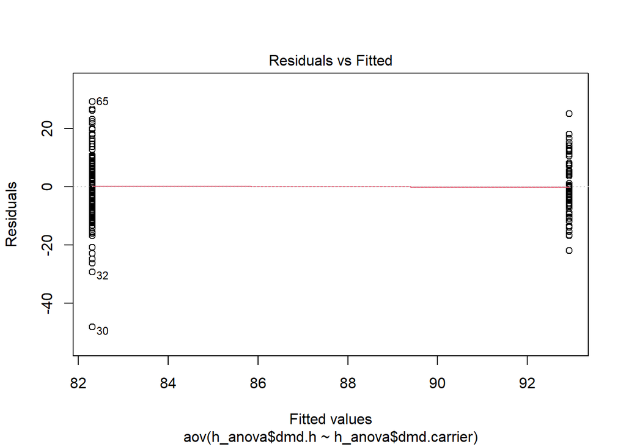

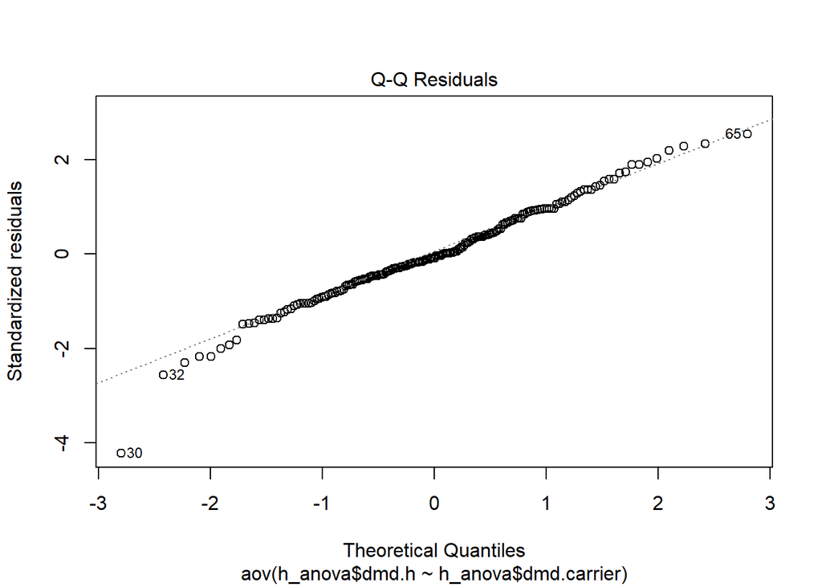

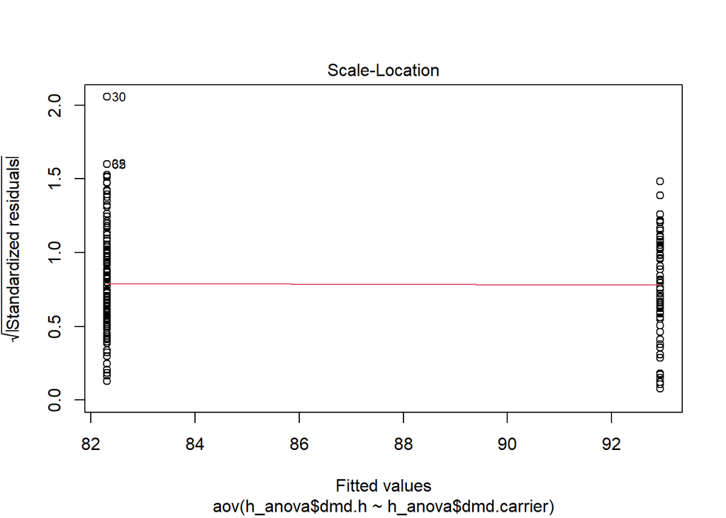

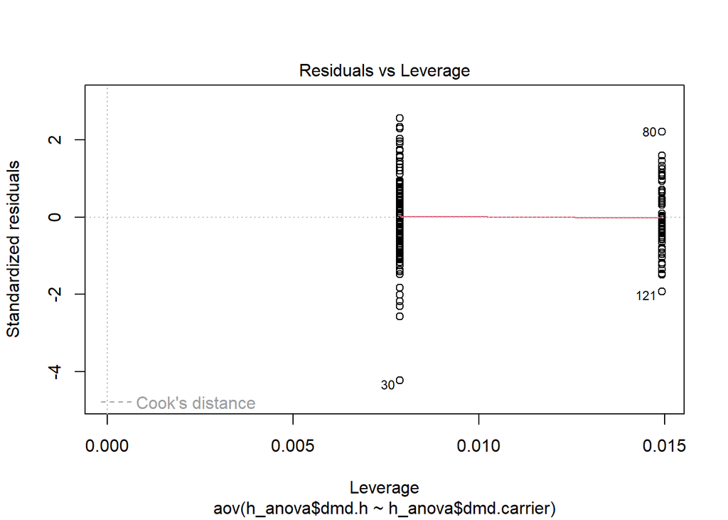

```r
plot(anova_h)
```

Como podemos observar, encontramos diferencias estadísticamente significativas entre ambos grupos.

**CONCLUSIONES**

Como hemos podido ver en el presente estudio, a priori, si que intuimos diferencias en los niveles de los diferentes marcadores entre los individuos sanos y las portadoras. En el caso de la hemopexina, que hemos estudiado más a fondo, podemos confirmar su poder como predictor de portadoras, ya que encontramos claras diferencias entre los distintos grupos. En el caso de los otros marcadores sería necesario un estudio mas a profundo.

También sería conveniente tener una muestra más equitativa entre grupos para poder evitar posibles sesgos y que sea más representativa de la población general.